# Part II - ((Pisa 2021: an overview of Math, reading and science students scores in ODCE and non ODCE countries)

## (Visualization 3)

> If we look now on top performer countries that have the most outperforming students Asiatics countries still lead inn every metrics That's the mark of educatif system that provide a high quality education for it students

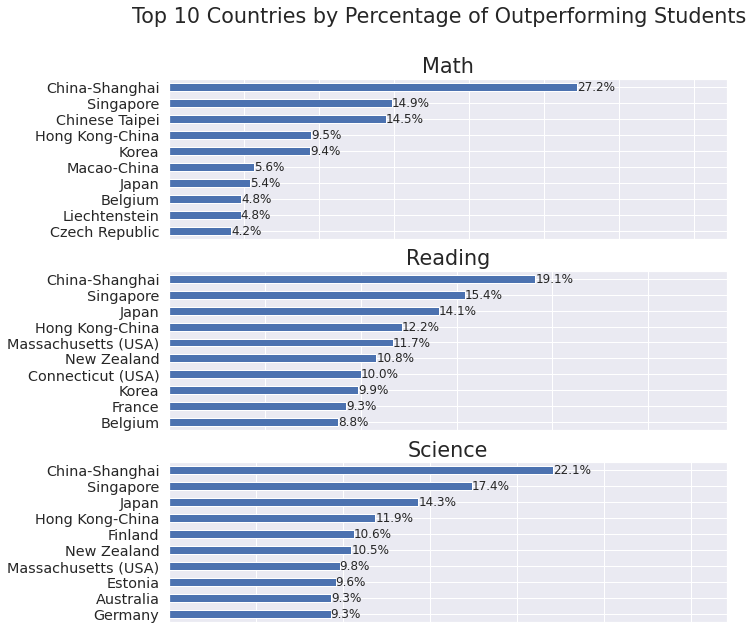

## (Visualization 4)

> OCDE in general a wealthy developped countries scores higher than non OCDE countries(oin MLath, Reading and Science), this maybe due to more ressources allocated to education

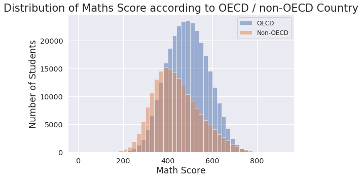

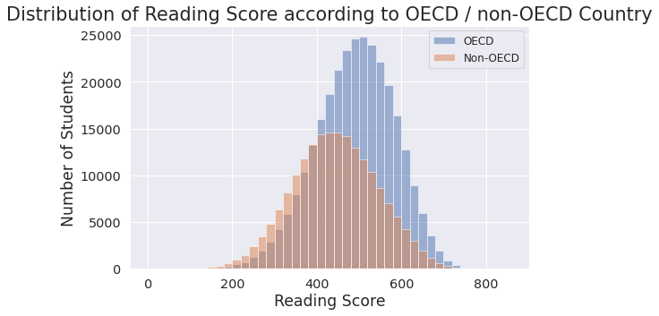

[figure not shown]

## (Visualization 5)

> If we compare between Math reading and science scores by a random sample of 1000 student and by gender we can see a positive corrolation between math, reading and science. We can also see that Male performls better on Math while Female better on reading, for science they both do equally.

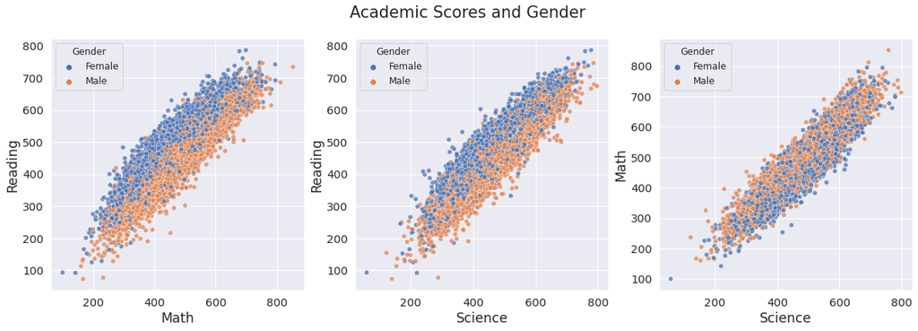

## (Visualization 6)

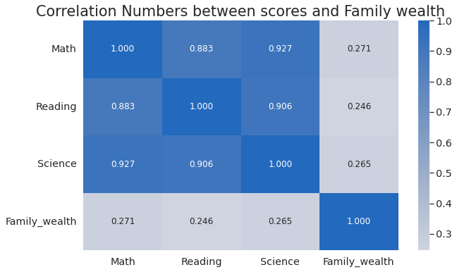

## (Visualization 7)

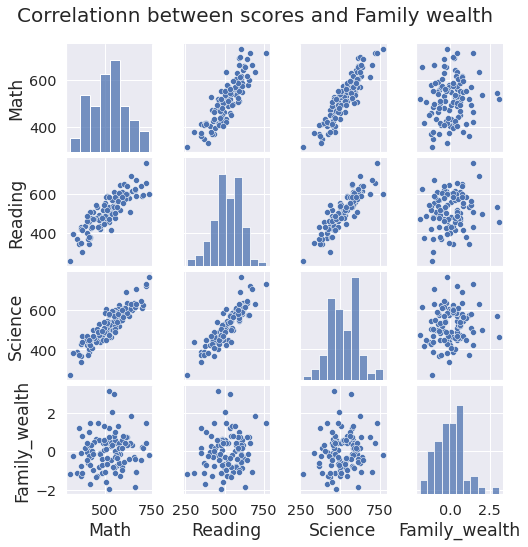

## (Visualization 8)

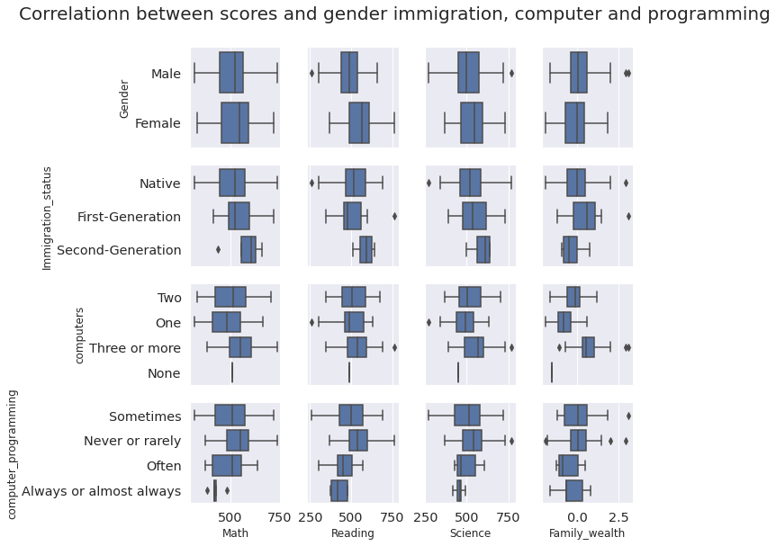

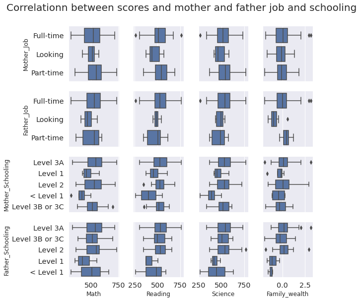